**Universidad Internacional de La Rioja (UNIR) - Máster Universitario en Inteligencia Artificial - Aprendizaje Automático**

Datos del alumno (Nombre y Apellidos): Jose Manuel Pinillos Rubio

Fecha: 11 de febrero de 2025

# Caso Grupal: Clasificación de mensajes de odio

## Objetivos

Mediante este trabajo se pretende que el estudiante ponga en práctica la aplicación de un proceso completo de machine learning a la clasificación de mensajes de odio.

El objetivo es generar un proyecto completo de machine learning para clasificar mensajes de odio. Debe detallar los pasos que hay que realizar para la clasificación de mensajes, así como una evaluación de los resultados.

- Decidir la técnica de aprendizaje automático a utilizar
- Analizar diferentes modelos de aprendizaje supervisado para la clasificación de mensajes de odio.
- Evaluar los resultados obtenidos por cada modelo en términos de precisión, *recall*, y *f1*.

## Descripción de la actividad

La empresa SureTech Innovations quiere implementar un clasificador de mensajes de odio. Para ello se deben entrenar diferentes modelos de clasificación, evaluar el rendimiento de cada uno de ellos, y finalmente, decidir cuál sería el mejor.

Para llevar a cabo esta actividad cuentas con el dataset simplificado de HateSpeech en la siguiente URL: https://github.com/almudenaris/TAA/blob/main/out.csv

Los pasos que se deben seguir para desarrollar esta actividad son:

1. ¿Qué tarea de aprendizaje automático se pretende resolver? ¿Qué análisis previos serían necesarios realizar para saber si es posible construir el modelo que buscamos? Realiza un análisis exploratorio de datos adecuado a la tarea que se pretende resolver y al dataset facilitado. Explica con detalle, en base a la tarea que se quiere resolver, qué análisis serían necesarios realizar sobre los datos.
2. En base a la tarea que se pide realizar y a las características del dataset decide qué algoritmo o algoritmos se deben utilizar. Implementa tres modelos. Realiza los entrenamientos necesarios para cada uno de ellos. Explica por qué son convenientes los algoritmos elegidos.
3. Realiza una explicación de las métricas de evaluación que se deben utilizar para valorar la bondad del modelo. Justifica la decisión de las elegidas. ¿Cómo habría que evaluar el modelo? Evalúa los modelos entrenados en el punto anterior y explica los resultados obtenidos.

## Dataset

El dataset original proporcionado en el proyecto transversal ha sido adaptado para la realización de esta actividad. Esa adaptación ha incluido:

- Eliminación de nulos y duplicados
- Eliminación de URLs, emojis y menciones a los periódicos
- Eliminación de filas vacías
- Limpieza y homogeneización de datos:
  - Convertir la totalidad del texto a minúscula
  - Eliminar signos de puntuación
  - Eliminar números
  - Eliminar espacios en blanco adicionales
  - Eliminar palabras con longitud menor a 2 caracteres
  - Eliminar *stopwords*
  - Tokenización
  - Lematización
- Proceso de extracción de características:
  - Conteo de palabras positivas (A)
  - Conteo de palabras negativas (B)
  - Conteo del número de bigrams más comunes (C)
  - Conteo del número de menciones a otros usuarios (D)
  - Categoría del sentimiento según librería ‘pysentimiento’ en español (E)
- Estandarización de las características (A_t,..E_t)
- Combinación de características $f_1*f_i$ (iA..iE) (Valor1,..Valor10).

*Nos encontramos ante un problema de clasificación binaria. Se pretende generar un modelo de aprendizaje supervisado para clasificar mensajes como "odio" (1) o "no odio" (0) en base al contexto y ciertas características.*

Antes de entrenar el modelo, es básico realizar un Análisis Exploratorio de Datos (EDA). Que nos permitirá tener una visión de la distribución de los datos. Análisis:

- Carga y revisión de los datos del dataset.
- Determinar si tenemos un dataset balanceado con respecto a la varibale objetivo.
- Revisar datos textuales (longitud promedio de los comentarios, frecuencia de palabras, etc..)
- Análisis de las correlaciones.

## ¿Qué tarea de aprendizaje automático se pretende resolver?

El problema planteado corresponde a una **tarea de clasificación binaria**, donde el objetivo es **clasificar mensajes en dos categorías: odio y no odio**. Dado que la variable objetivo (`label`) tiene dos posibles valores (`0` y `1`), el modelo deberá aprender a asignar correctamente cada mensaje a una de estas clases en función de sus características.

Esta es una tarea típica de **aprendizaje supervisado**, ya que contamos con un conjunto de datos etiquetado, donde cada mensaje ya ha sido clasificado previamente. El modelo utilizará estas etiquetas durante la fase de entrenamiento para identificar patrones en los datos y, posteriormente, podrá predecir la clase de nuevos mensajes no etiquetados.

Además, debido a la naturaleza textual de los datos, el problema también puede considerarse un caso de **procesamiento de lenguaje natural (NLP)**, en el que es necesario extraer características relevantes del texto, como la frecuencia de palabras, la presencia de entidades nombradas y la distribución de términos clave en cada clase.

## ¿Qué análisis previos serían necesarios realizar para saber si es posible construir el modelo que buscamos?

Antes de construir el modelo, es fundamental realizar un **análisis exploratorio de datos (EDA)** que permita evaluar la calidad y estructura de los datos, identificar patrones y tomar decisiones sobre posibles ajustes o preprocesamientos. Los análisis previos necesarios incluyen:

1. **Comprensión de la estructura del dataset**: Se debe examinar el conjunto de datos para entender **qué variables están disponibles** y cuál es su naturaleza. En este caso, el dataset ya ha sido preprocesado, por lo que los comentarios están representados como **tokens separados por comas**, y se dispone de una serie de características extraídas del texto.
2. **Identificación de datos inconsistentes o duplicados**: Es importante verificar si hay **mensajes duplicados o inconsistentes**, ya que estos podrían afectar la generalización del modelo. En este caso, el dataset ya ha sido limpiado en la etapa de preprocesamiento, por lo que no es necesario realizar esta corrección.
3. **Análisis de la variable objetivo**: Es esencial evaluar la **distribución de la variable `label`** para determinar si el dataset está balanceado. Un desequilibrio significativo entre clases podría afectar el rendimiento del modelo y requerir estrategias de ajuste, como reponderación de clases o generación de datos sintéticos.
4. **Clasificación y análisis de las variables**: Se debe diferenciar entre **variables numéricas y categóricas**, así como identificar cuáles son **continuas y discretas**. Esto ayuda a determinar los métodos de normalización, transformación y selección de características más adecuados.
5. **Análisis de la distribución de las variables continuas**:: Se debe evaluar la **dispersión y rango de valores** de las variables numéricas para detectar la presencia de valores extremos o distribuciones sesgadas que podrían afectar el rendimiento del modelo.
6. **Análisis de correlación entre variables**: Es importante identificar si existen **relaciones fuertes entre las variables** para evaluar la posibilidad de eliminar aquellas que aportan información redundante o combinarlas para mejorar la eficiencia del modelo. Se deben analizar:
- **Correlaciones entre variables continuas** para detectar relaciones lineales.
- **Correlación entre variables continuas y la variable objetivo** para conocer qué características están más asociadas con la clasificación de odio y no odio.
- **Correlaciones entre variables categóricas** para encontrar dependencias en los datos.
- **Correlación entre variables categóricas y la variable objetivo** para entender la influencia de las categorías en la clasificación.
7. **Análisis de características textuales**: Dado que la clasificación se basa en mensajes de texto, es necesario evaluar cómo se estructuran y qué patrones lingüísticos contienen. Para ello, se analizan aspectos como:
- **Número total de palabras en el corpus** y su distribución.
- **Cantidad promedio de palabras por comentario** y cómo varía entre los grupos de odio y no odio.
- **Presencia de entidades nombradas (NER)** para detectar referencias a personas, lugares y organizaciones.
- **Distribución de los lemas más frecuentes en cada grupo** para identificar diferencias en el lenguaje utilizado.

## 1. Análisis Exploratiorio de los datos (EDA)

```python
# Importamos las librerias necesarias
import numpy as np
import pandas as pd
import matplotlib.pyplot as plt
import seaborn as sns
from collections import Counter
from sklearn.preprocessing import StandardScaler
!python -m spacy download es_core_news_md
import es_core_news_md
from scipy.stats import pointbiserialr
import scipy.stats as stats
```

[output not shown]

### 1.1 - Cargar el *dataset*

```python
# Cargamos el dataset
df = pd.read_csv("out.csv")
```

### 1.2 - Visualización de información contenido

```python
# Mostramos información general
print("Información del dataset:")
print(df.info())
```

```
Información del dataset:
<class 'pandas.core.frame.DataFrame'>
RangeIndex: 10000 entries, 0 to 9999
Data columns (total 22 columns):
 #   Column      Non-Null Count  Dtype
---  ------      --------------  -----
 0   A           10000 non-null  int64
 1   B           10000 non-null  int64
 2   C           10000 non-null  int64
 3   D           10000 non-null  int64
 4   E           10000 non-null  int64
 5   comentario  10000 non-null  object
 6   label       10000 non-null  float64
 7   A_t         10000 non-null  float64
 8   B_t         10000 non-null  float64
```

[output cut: 16 more lines]

El dataset consta de **10,000 registros** y **22 columnas**, incluyendo variables numéricas y una columna de texto que contiene los comentarios. Todas las columnas tienen valores completos, es decir, no hay valores nulos en el conjunto de datos.

Las primeras cinco columnas (**A, B, C, D y E**) son de tipo `int64` y probablemente representen conteos de diferentes características extraídas del texto. La columna **comentario** es de tipo `object`, lo que indica que contiene texto en formato cadena. La columna **label**, que es de tipo `float64`, representa la variable objetivo, donde se clasifica el mensaje como **"odio" (1) o "no odio" (0)**.

Además, hay versiones normalizadas de las cinco primeras variables (**A_t, B_t, C_t, D_t y E_t**), todas de tipo `float64`. También se incluyen combinaciones de características denominadas **Valor_1** a **Valor_10**, que también son de tipo `float64`.

El tamaño en memoria del dataset es de aproximadamente **1.7 MB**, lo que lo hace manejable para procesamiento en memoria sin necesidad de optimización inmediata.

```python
# Mostramos las 5 primeras filas del dataset
df.head()
```

|  | A | B | C | D | E | comentario | label | A_t | B_t | C_t | ... | Valor_1 | Valor_2 | Valor_3 | Valor_4 | Valor_5 | Valor_6 | Valor_7 | Valor_8 | Valor_9 | Valor_10 |
| --- | --- | --- | --- | --- | --- | --- | --- | --- | --- | --- | --- | --- | --- | --- | --- | --- | --- | --- | --- | --- | --- |
| 0 | 2 | 64 | 30 | 0 | 2 | pandemia,originado,covid,cierto,incidencia,aba... | 0.0 | 1.851102 | 2.759647 | 7.145831 | ... | 5.108388 | 13.227660 | -0.771127 | 0.815665 | 19.719970 | -1.149606 | 1.216004 | -2.976790 | 3.148722 | -0.183560 |
| 1 | 4 | 70 | 21 | 0 | 0 | ser,mes,larga,espera,llegar,momento,siempre,pr... | 0.0 | 3.990202 | 3.054765 | 4.877255 | ... | 12.189130 | 19.461233 | -1.662227 | -2.119191 | 14.898871 | -1.272546 | -1.622382 | -2.031754 | -2.590305 | 0.221244 |
| 2 | 4 | 88 | 50 | 0 | 0 | cartagena,san,sebastiar,fuengirola,irun,orense... | 0.0 | 3.990202 | 3.940120 | 12.187108 | ... | 15.721875 | 48.629021 | -1.662227 | -2.119191 | 48.018675 | -1.641365 | -2.092593 | -5.076872 | -6.472559 | 0.221244 |
| 3 | 3 | 38 | 21 | 0 | 0 | pleno,dia,verano,calor,plan,mas,apetecibl,disf... | 0.0 | 2.920652 | 1.480801 | 4.877255 | ... | 4.324903 | 14.244765 | -1.216677 | -1.551155 | 7.222244 | -0.616868 | -0.786452 | -2.031754 | -2.590305 | 0.221244 |
| 4 | 0 | 59 | 17 | 0 | 0 | pasado,junio,celebro,dia,luchar,frente,leishma... | 0.0 | -0.287998 | 2.513715 | 3.869000 | ... | -0.723945 | -1.114264 | 0.119973 | 0.152955 | 9.725563 | -1.047156 | -1.335031 | -1.611737 | -2.054821 | 0.221244 |

5 rows × 22 columns

Las primeras cinco filas del dataset muestran cómo están estructurados los datos. Cada fila representa un comentario con sus respectivas características numéricas y la etiqueta de clasificación.

Las columnas **A, B, C, D y E** contienen valores enteros que representan el resultado del análisis de características del texto, como el **conteo de palabras positivas y negativas**, la cantidad de **bigrams** más comunes y las menciones a otros usuarios.

La columna **comentario** almacena el texto procesado de los mensajes, con palabras lematizadas y sin signos de puntuación ni caracteres irrelevantes.

La columna **label** indica si el comentario es clasificado como odio (**1.0**) o no odio (**0.0**). En estas primeras cinco filas, todos los mensajes están etiquetados como **0.0**, es decir, no contienen discurso de odio.

Las columnas **A_t, B_t, C_t, D_t y E_t** representan versiones estandarizadas de las variables **A-E**, asegurando que los valores estén en una escala comparable.

Las columnas **Valor_1 a Valor_10** contienen combinaciones de características ($f_1 * f_i$), que podrían ser interacciones entre las variables originales.

El contenido del dataset sugiere que ya se ha realizado una limpieza y preprocesamiento avanzado, dejando los datos listos para la exploración estadística y la construcción de modelos de clasificación.

### 1.3 - Distribución de la variable objetivo

```python
# usamos la opcion df.shape para obtener la cantidad de instancias.
print(f'El dataset contiene {df.shape[0]} instancias.')
```

```
El dataset contiene 10000 instancias.
```

El dataset contiene **10,000 instancias**, lo que indica que hay **10,000 comentarios** etiquetados y listos para el análisis. Este tamaño de muestra es adecuado para entrenar modelos de aprendizaje automático sin requerir técnicas de reducción de datos. Sin embargo, es importante verificar el **balanceo de la variable objetivo (`label`)** para asegurarnos de que el conjunto de datos no esté desbalanceado, lo que podría afectar el rendimiento del modelo de clasificación.

```python
# Realizamos un conteo de los ejemplos catalogados como odio o no odio
df['label'].value_counts()
```

| label | count |
| --- | --- |
| 0.0 | 5000 |
| 1.0 | 5000 |

**dtype:** int64

El dataset está **balanceado**, con **5,000 instancias de "no odio" (0.0) y 5,000 instancias de "odio" (1.0)**. Esto es ideal para el entrenamiento de modelos de clasificación, ya que evita el problema del **desbalanceo de clases**, donde un modelo podría sesgarse hacia la clase mayoritaria.

Dado que ambas clases tienen la misma cantidad de ejemplos, las métricas de evaluación como **precisión, recall y F1-score** no se verán afectadas por un sesgo de distribución. Sin embargo, será recomendable verificar este balance también en los conjuntos de **entrenamiento y prueba** una vez que se realice la partición de los datos.

### 1.4 - Análisis y clasificación de las variables

```python
# Inicializamos listas para cada tipo de variable
categorical_variables = []
binary_variables = []
multiclass_variables = []
continuous_variables = []

# Definimos un umbral para diferenciar entre variables multiclase y continuas
multiclass_threshold = 10  # Si una variable numérica tiene menos de 10 valores únicos, es multiclase

# Iteramos sobre todas las columnas del dataset
for column in df.columns:
    unique_values = df[column].nunique()  # Número de valores únicos
    dtype = df[column].dtype  # Tipo de dato de la columna

    # Si la variable es de tipo 'object', se considera categórica
    if dtype == 'object':
        categorical_variables.append(column)

    # Si la variable es numérica
    elif dtype in ['int64', 'float64']:
        # Si tiene solo dos valores únicos (por ejemplo, 0 y 1), es binaria
        if unique_values == 2:
            binary_variables.append(column)
        # Si tiene pocos valores únicos, se considera multiclase
        elif unique_values < multiclass_threshold:
            multiclass_variables.append(column)
        # Si tiene muchos valores únicos, se considera continua
        else:
            continuous_variables.append(column)

# Mostramos los resultados
print(f'Variables categóricas ({len(categorical_variables)}): {categorical_variables}')
print(f'Variables binarias ({len(binary_variables)}): {binary_variables}')
print(f'Variables multiclase ({len(multiclass_variables)}): {multiclass_variables}')
print(f'Variables continuas ({len(continuous_variables)}): {continuous_variables}')
```

```
Variables categóricas (1): ['comentario']
Variables binarias (1): ['label']
Variables multiclase (4): ['D', 'E', 'D_t', 'E_t']
Variables continuas (16): ['A', 'B', 'C', 'A_t', 'B_t', 'C_t', 'Valor_1', 'Valor_2', 'Valor_3', 'Valor_4', 'Valor_5', 'Valor_6', 'Valor_7', 'Valor_8', 'Valor_9', 'Valor_10']
```

El código tiene como objetivo **clasificar las variables del dataset** en **categóricas y continuas**, basándose en su tipo de dato y en el número de valores únicos que contienen.

Primero, se inicializan listas vacías para cada tipo de variable y se define un umbral (`multiclass_threshold = 10`) para diferenciar entre variables categóricas y continuas. Luego, se recorre cada columna del dataset verificando su tipo de dato. Si una columna es de tipo `object`, se clasifica como **categórica**. Si es numérica (`int64` o `float64`), se evalúa su número de valores únicos y su significado en el contexto de la actividad.

A partir del análisis realizado y considerando la descripción del dataset, se concluye que las variables `E` y `E_t`, que representan la **categoría de sentimiento** según *pysentimiento*, deben clasificarse como **categóricas**, ya que contienen valores predefinidos de sentimiento. Por otro lado, `D` y `D_t`, que representan el **conteo de menciones a otros usuarios**, deben considerarse **continuas**, ya que son variables numéricas derivadas del análisis del texto.

De esta manera, la clasificación final de las variables queda establecida de la siguiente manera:

- **4 categóricas:** `comentario`, `label`, `E`, `E_t`
- **18 continuas:** `A`, `B`, `C`, `D`, `A_t`, `B_t`, `C_t`, `D_t`, `Valor_1`, `Valor_2`, `Valor_3`, `Valor_4`, `Valor_5`, `Valor_6`, `Valor_7`, `Valor_8`, `Valor_9`, `Valor_10`

```python
# Iteramos sobre las variables multiclase corregidas (E y E_t)
for column in ['E', 'E_t']:
    # Obtenemos los valores únicos de la columna actual
    unique_vals = df[column].unique()

    # Mostramos la cantidad de valores únicos y cuáles son
    print(f"{column}: {len(unique_vals)} valores únicos -> {unique_vals}")
```

```
E: 7 valores únicos -> [2 0 1 6 3 4 5]
E_t: 7 valores únicos -> [ 0.44063766 -0.53109882 -0.04523058  2.38411063  0.9265059   1.41237415
  1.89824239]
```

El código tiene como objetivo **verificar que las variables categóricas multiclase han sido correctamente clasificadas**, revisando la cantidad de valores únicos que toman en el dataset. Esto permite confirmar que efectivamente son **categóricas con múltiples clases** y no continuas.

Para ello, se itera sobre las variables `E` y `E_t`, obteniendo sus valores únicos con `df[column].unique()`. Luego, se imprime el nombre de la variable, la cantidad de valores distintos que tiene y la lista de esos valores. Este análisis es fundamental para confirmar que **E y E_t** contienen un número limitado de clases, lo que respalda su categorización como variables discretas en lugar de continuas.

Los resultados muestran que **E y E_t tienen exactamente 7 valores únicos**, lo que confirma que **representan categorías discretas bien definidas**. La variable `E` corresponde a la **categoría de sentimiento** asignada por *pysentimiento*, lo que indica que contiene etiquetas predefinidas. La variable `E_t`, por su parte, es una versión transformada o escalada de `E`, pero sigue manteniendo el mismo número de clases.

```python
# Ajustamos las variables categóricas y continuas
multiclass_variables = ['E', 'E_t']  # Solo mantenemos las variables categóricas multiclase
continuous_variables.extend(['D', 'D_t'])  # Agregamos D y D_t a las continuas

# Reordenamos las variables continuas para que D y D_t aparezcan en la posición deseada
continuous_variables = ['A', 'B', 'C', 'D', 'A_t', 'B_t', 'C_t', 'D_t',
                        'Valor_1', 'Valor_2', 'Valor_3', 'Valor_4', 'Valor_5',
                        'Valor_6', 'Valor_7', 'Valor_8', 'Valor_9', 'Valor_10']

# Creamos un DataFrame con las variables categóricas
df_categorical = df[categorical_variables + binary_variables + multiclass_variables]

# Creamos un DataFrame con las variables continuas reordenadas
df_continuous = df[continuous_variables]

# Verificamos la estructura de ambos DataFrames
print(f'DF categórico: {df_categorical.shape[0]} filas, {df_categorical.shape[1]} columnas')
display(df_categorical.head())
print(f'\nDF continuo: {df_continuous.shape[0]} filas, {df_continuous.shape[1]} columnas')
display(df_continuous.head())
```

```
DF categórico: 10000 filas, 4 columnas
```

|  | comentario | label | E | E_t |
| --- | --- | --- | --- | --- |
| 0 | pandemia,originado,covid,cierto,incidencia,aba... | 0.0 | 2 | 0.440638 |
| 1 | ser,mes,larga,espera,llegar,momento,siempre,pr... | 0.0 | 0 | -0.531099 |
| 2 | cartagena,san,sebastiar,fuengirola,irun,orense... | 0.0 | 0 | -0.531099 |
| 3 | pleno,dia,verano,calor,plan,mas,apetecibl,disf... | 0.0 | 0 | -0.531099 |
| 4 | pasado,junio,celebro,dia,luchar,frente,leishma... | 0.0 | 0 | -0.531099 |

```
DF continuo: 10000 filas, 18 columnas
```

|  | A | B | C | D | A_t | B_t | C_t | D_t | Valor_1 | Valor_2 | Valor_3 | Valor_4 | Valor_5 | Valor_6 | Valor_7 | Valor_8 | Valor_9 | Valor_10 |
| --- | --- | --- | --- | --- | --- | --- | --- | --- | --- | --- | --- | --- | --- | --- | --- | --- | --- | --- |
| 0 | 2 | 64 | 30 | 0 | 1.851102 | 2.759647 | 7.145831 | -0.416577 | 5.108388 | 13.227660 | -0.771127 | 0.815665 | 19.719970 | -1.149606 | 1.216004 | -2.976790 | 3.148722 | -0.183560 |
| 1 | 4 | 70 | 21 | 0 | 3.990202 | 3.054765 | 4.877255 | -0.416577 | 12.189130 | 19.461233 | -1.662227 | -2.119191 | 14.898871 | -1.272546 | -1.622382 | -2.031754 | -2.590305 | 0.221244 |
| 2 | 4 | 88 | 50 | 0 | 3.990202 | 3.940120 | 12.187108 | -0.416577 | 15.721875 | 48.629021 | -1.662227 | -2.119191 | 48.018675 | -1.641365 | -2.092593 | -5.076872 | -6.472559 | 0.221244 |
| 3 | 3 | 38 | 21 | 0 | 2.920652 | 1.480801 | 4.877255 | -0.416577 | 4.324903 | 14.244765 | -1.216677 | -1.551155 | 7.222244 | -0.616868 | -0.786452 | -2.031754 | -2.590305 | 0.221244 |
| 4 | 0 | 59 | 17 | 0 | -0.287998 | 2.513715 | 3.869000 | -0.416577 | -0.723945 | -1.114264 | 0.119973 | 0.152955 | 9.725563 | -1.047156 | -1.335031 | -1.611737 | -2.054821 | 0.221244 |

### 1.5 - Análisis de la distribución de las variables continuas

```python
# Generamos un resumen estadístico de las variables continuas
df_continuous.describe()
```

|  | A | B | C | D | A_t | B_t | C_t | D_t | Valor_1 | Valor_2 | Valor_3 | Valor_4 | Valor_5 | Valor_6 | Valor_7 | Valor_8 | Valor_9 | Valor_10 |
| --- | --- | --- | --- | --- | --- | --- | --- | --- | --- | --- | --- | --- | --- | --- | --- | --- | --- | --- |
| count | 10000.000000 | 10000.000000 | 10000.000000 | 10000.000000 | 10000.000000 | 10000.000000 | 10000.000000 | 10000.000000 | 10000.000000 | 10000.000000 | 10000.000000 | 10000.000000 | 10000.000000 | 10000.000000 | 10000.000000 | 10000.000000 | 10000.000000 | 10000.000000 |
| mean | 0.957400 | 26.098100 | 5.674600 | 0.091300 | 0.735989 | 0.895389 | 1.014276 | -0.241571 | 2.448370 | 2.515129 | -0.222304 | -0.324603 | 3.343632 | -0.302639 | -0.756762 | -0.286422 | -0.357238 | -0.050935 |
| std | 1.741864 | 34.012341 | 7.317149 | 0.352671 | 1.863010 | 1.672944 | 1.844389 | 0.676008 | 8.690527 | 9.827254 | 1.160914 | 1.547278 | 10.567912 | 1.045447 | 0.885760 | 1.218960 | 1.297408 | 1.129825 |
| min | 0.000000 | 0.000000 | 0.000000 | 0.000000 | -0.287998 | -0.388282 | -0.416086 | -0.416577 | -2.197166 | -3.582457 | -10.573231 | -11.207779 | -1.393841 | -6.558948 | -8.362074 | -9.067027 | -11.559651 | -5.886890 |
| 25% | 0.000000 | 1.000000 | 1.000000 | 0.000000 | -0.287998 | -0.339096 | -0.164022 | -0.416577 | -0.086494 | -0.097950 | -0.432068 | -0.686619 | -0.025057 | -0.760297 | -0.943189 | -0.561697 | -0.716113 | -0.993166 |
| 50% | 0.000000 | 5.000000 | 3.000000 | 0.000000 | -0.287998 | -0.142350 | 0.340105 | -0.416577 | 0.097659 | 0.047238 | 0.119973 | -0.415081 | 0.063687 | -0.043150 | -0.808442 | -0.141680 | -0.314500 | 0.221244 |
| 75% | 1.000000 | 46.000000 | 7.000000 | 0.000000 | 0.781552 | 1.874292 | 1.348361 | -0.416577 | 1.157323 | 0.659812 | 0.119973 | 0.152955 | 2.527222 | 0.141260 | -0.314174 | 0.068328 | 0.087112 | 0.221244 |
| max | 24.000000 | 328.000000 | 88.000000 | 6.000000 | 25.381200 | 15.744855 | 21.765536 | 11.084360 | 332.263677 | 246.545947 | 21.283302 | 60.511589 | 331.989523 | 20.009412 | 19.361276 | 28.053013 | 23.045933 | 17.286505 |

El código genera un **resumen estadístico** de las variables continuas, proporcionando información clave sobre su distribución. Se observa que todas las variables tienen **10,000 valores**, lo que indica que no hay valores nulos. La **media (`mean`)** muestra el valor promedio de cada variable, mientras que la **desviación estándar (`std`)** refleja la dispersión de los datos respecto a la media, permitiendo evaluar la variabilidad dentro del dataset.

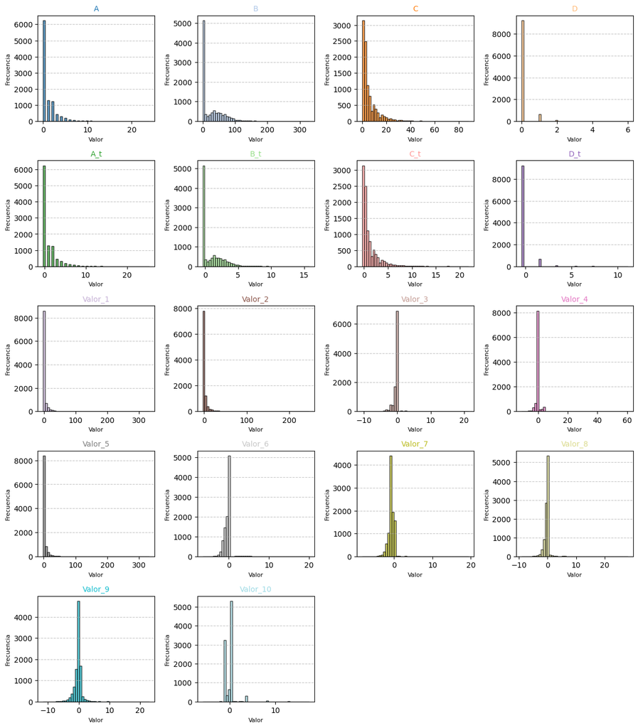

```python
# Configuración de la matriz de gráficos para las variables continuas reales
rows, cols = 6, 4  # Ajustamos filas y columnas según la cantidad de variables continuas
fig, axes = plt.subplots(rows, cols, figsize=(12, 16))
axes = axes.flatten()  # Aplanamos la matriz de ejes para iterar fácilmente

# Definimos colores únicos para cada gráfico con más variedad
colors = plt.cm.get_cmap('tab20', len(df_continuous.columns)).colors

# Creamos un histograma para cada variable continua
for i, variable in enumerate(df_continuous.columns):
    axes[i].hist(df_continuous[variable], bins=50, color=colors[i % len(colors)], alpha=0.7, edgecolor='black')
    axes[i].set_title(variable, fontsize=10, color=colors[i % len(colors)])
    axes[i].set_xlabel('Valor', fontsize=8)
    axes[i].set_ylabel('Frecuencia', fontsize=8)
    axes[i].grid(axis='y', linestyle='--', alpha=0.7)

# Eliminamos ejes vacíos si hay más gráficos que variables
for j in range(len(df_continuous.columns), len(axes)):
    fig.delaxes(axes[j])

# Ajustamos automáticamente los márgenes entre los gráficos
plt.tight_layout()

# Mostramos el gráfico
plt.show()
```

El código genera **histogramas** para analizar la distribución de cada variable continua del dataset. Se configura una **matriz de gráficos** de **6 filas por 4 columnas**, asegurando una disposición clara y organizada. Se asignan **colores únicos** utilizando la paleta `tab20`, lo que facilita la diferenciación visual entre variables.

Cada histograma se construye con **50 bins**, proporcionando una vista detallada de la distribución de los datos. Se incluyen etiquetas en los ejes y una cuadrícula en el eje `y` para mejorar la legibilidad. Además, se eliminan los ejes vacíos si hay más subgráficos que variables y se ajustan los márgenes para evitar solapamientos.

El análisis de los histogramas revela que la mayoría de las variables, como **A, B, C, D, A_t, B_t, C_t, D_t**, muestran una **distribución sesgada a la derecha**, con valores bajos predominantes y una cola larga hacia valores altos. Esto sugiere que la mayoría de las observaciones se concentran en rangos bajos, pero existen valores extremos que podrían influir en el modelo.

Las variables **Valor_1, Valor_2, Valor_3, Valor_4, Valor_5** presentan **distribuciones con acumulaciones en puntos específicos**, lo que podría indicar la presencia de **valores atípicos**. En cambio, otras variables como **Valor_6, Valor_7, Valor_8, Valor_9, Valor_10** exhiben distribuciones más equilibradas, sugiriendo que podrían estar mejor distribuidas y requerir menos transformación antes del modelado.

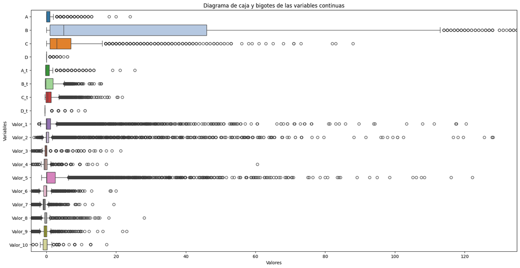

```python
# Configuración de la figura para los boxplots en orientación horizontal
plt.figure(figsize=(20, 10))

# Creamos un boxplot con orientación horizontal
sns.boxplot(data=df_continuous, palette="tab20", orient="h")

# Ajustamos las etiquetas y el título
plt.yticks(fontsize=10)  # Ajustamos el tamaño de las etiquetas de las variables
plt.title("Diagrama de caja y bigotes de las variables continuas", fontsize=12)
plt.xlabel("Valores", fontsize=10)
plt.ylabel("Variables", fontsize=10)

# Ajustamos la escala del eje X para hacer más visibles las cajas
plt.xlim(df_continuous.quantile(0.01).min(), df_continuous.quantile(0.99).max())

# Mostramos el gráfico
plt.show()
```

El código genera un **diagrama de caja y bigotes en orientación horizontal** para analizar la distribución de las variables continuas y detectar valores atípicos. Primero, se configura una figura de **20x10** para asegurar que todas las variables sean visibles sin solapamientos. Luego, se utiliza `sns.boxplot()` con la opción `orient="h"` para representar los datos de manera horizontal, lo que facilita la comparación entre variables.

Se aplica la paleta de colores `"tab20"` para diferenciar cada variable y se ajustan las etiquetas de los ejes para mejorar la legibilidad. Además, se define un límite en el eje **X** con `plt.xlim(df_continuous.quantile(0.01).min(), df_continuous.quantile(0.99).max())`, lo que permite excluir los valores más extremos y mejorar la visualización de las cajas. Finalmente, se muestra el gráfico con `plt.show()`, permitiendo analizar la dispersión de los datos y la presencia de valores atípicos.

El diagrama muestra la distribución de las variables continuas y revela la presencia de un número significativo de valores atípicos en varias de ellas. Se observa que variables como **B, C, D, Valor_1, Valor_2, Valor_3, Valor_4, Valor_5**, entre otras, presentan muchos puntos fuera de los bigotes, lo que indica que hay observaciones con valores alejadas del rango intercuartílico. La inclusión de **D y D_t** confirma que estas variables también presentan valores extremos, aunque en menor medida que otras como **B**.

La presencia de estos valores atípicos puede influir en el análisis posterior, ya que pueden estar asociados a características particulares de los datos que afectan su distribución. Sin embargo, dado que el dataset ya ha sido preprocesado, estos valores no necesariamente indican errores, sino que forman parte de su estructura. En este caso, en lugar de eliminarlos, es importante considerar su impacto en el análisis y en la fase de modelado.

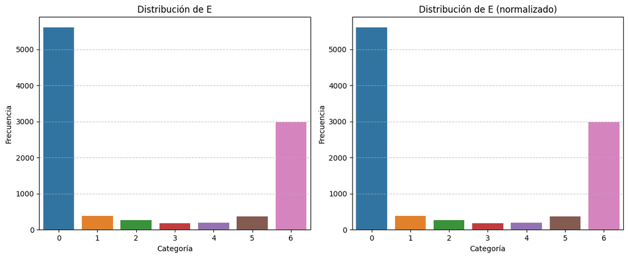

```python
# Variables categóricas a graficar
categorical_vars = ['E', 'E_t']

# Aseguramos que las variables sean categóricas
for var in categorical_vars:
    df[var] = df[var].astype('category')

# Diccionario para mapear valores de E_t a sus categorías originales
# Esto asume que E_t es una versión normalizada de E
mapping_E_t = dict(zip(sorted(df["E_t"].unique()), sorted(df["E"].unique())))

# Aplicamos la transformación para que E_t muestre las mismas categorías que E
df["E_t_mapped"] = df["E_t"].map(mapping_E_t)

# Configuración de la figura con subgráficos
fig, axes = plt.subplots(nrows=1, ncols=2, figsize=(12, 5))

# Variables a graficar después del mapeo
variables_mapeadas = ["E", "E_t_mapped"]
titulos = ["E", "E (normalizado)"]

# Crear un gráfico de barras para cada variable categórica con nombres correctos
for i, var in enumerate(variables_mapeadas):
    sns.countplot(data=df, x=var, hue=var, palette="tab10", ax=axes[i], legend=False)
    axes[i].set_title(f"Distribución de {titulos[i]}")
    axes[i].set_xlabel("Categoría")
    axes[i].set_ylabel("Frecuencia")
    axes[i].grid(axis='y', linestyle='--', alpha=0.7)

# Ajustar el diseño para evitar solapamientos
plt.tight_layout()

# Mostrar los gráficos
plt.show()
```

El código genera **gráficos de barras** para analizar la distribución de las variables categóricas **E y E_t**, excluyendo D y D_t, ya que estas últimas han sido reclasificadas como variables continuas. Se utiliza `sns.countplot()` para representar la frecuencia de cada categoría en estas variables, lo que permite identificar su distribución en el dataset.

Primero, se convierten las variables categóricas a tipo `category` para optimizar su manejo. Luego, dado que `E_t` es una versión transformada de `E`, se crea un **diccionario de mapeo** (`mapping_E_t`) que permite asociar los valores de `E_t` con sus categorías originales en `E`, asegurando que ambas mantengan la misma correspondencia.

Los gráficos se presentan en **dos subgráficos**, uno para `E` y otro para `E_t_mapped`, con una disposición horizontal (`figsize=(12,5)`) para mejorar la visualización. Se aplican colores diferenciados con la paleta `"tab10"`, y se activan líneas de referencia en el eje `y` para facilitar la interpretación de la frecuencia de cada categoría.

Los resultados muestran que `E` y `E_t` tienen la misma cantidad de categorías, lo que confirma que `E_t` es una versión transformada de `E`, manteniendo la misma estructura de distribución. Esto permite validar que la normalización de `E_t` respeta las categorías originales sin introducir sesgos en la clasificación.

### 1.6 - Análisis de correlación entre variables

En esta sección se analizarán las relaciones entre las variables del dataset para identificar posibles redundancias y evaluar su impacto en la variable objetivo. Dado que el conjunto de datos contiene tanto variables **continuas** como **categóricas**, se aplicarán diferentes métricas según el tipo de variable.

Primero, se calculará la **correlación de Pearson** entre las variables continuas para detectar relaciones lineales entre ellas. Luego, se medirá la correlación entre las variables continuas y la variable objetivo (`label`) mediante **correlación punto-biserial**, dado que `label` es una variable binaria. Posteriormente, se analizará la relación entre las variables categóricas con **Chi-cuadrado (χ²)**, tanto entre sí como con la variable objetivo.

Este análisis permitirá determinar si algunas variables aportan información redundante o si existen relaciones significativas con `label`, lo que puede influir en la selección de características para los modelos de clasificación.

#### 1.6.1 - Correlación entre variables continuas

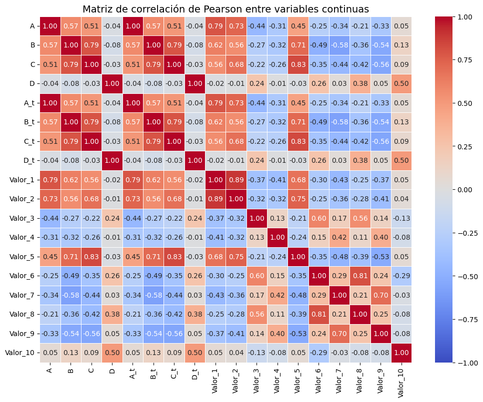

```python
# Calculamos la matriz de correlación de Pearson para las variables continuas
corr_matrix = df_continuous.corr(method='pearson')

# Configuramos del heatmap
plt.figure(figsize=(12, 9))
sns.heatmap(corr_matrix, annot=True, fmt=".2f", cmap="coolwarm", linewidths=0.5, vmin=-1, vmax=1)

# Ajustamos de título y etiquetas
plt.title("Matriz de correlación de Pearson entre variables continuas", fontsize=14)
plt.xticks(rotation=90)
plt.yticks(rotation=0)

# Mostramos el gráfico
plt.show()
```

El código genera una **matriz de correlación de Pearson** para analizar la relación entre las variables continuas, incluyendo ahora las recientemente incorporadas `D` y `D_t`. Se utiliza `df_continuous.corr(method='pearson')` para calcular los coeficientes de correlación entre todas las variables y luego se visualiza con `sns.heatmap()`, aplicando la paleta `"coolwarm"` para diferenciar las correlaciones positivas y negativas. Se configuran los valores dentro de las celdas (`annot=True`) y se ajustan las etiquetas para mejorar la legibilidad.

Por otro lado, se mantienen las correlaciones altas entre `A`, `B`, `C` y sus versiones normalizadas (`A_t`, `B_t`, `C_t`), lo que confirma que estas transformaciones han mantenido la estructura de los datos con una escala ajustada. También se observa una relación fuerte entre algunas variables derivadas, como `Valor_1` y `Valor_2`, lo que sugiere que podrían capturar información similar.

Dado que el *dataset* ya ha sido preprocesado y ajustado, la correlación por sí sola no justifica la eliminación de variables. Antes de tomar decisiones sobre reducción de dimensionalidad, sería necesario evaluar su impacto en la clasificación y comprobar si estas correlaciones afectan negativamente el rendimiento del modelo.

#### 1.6.2 - Correlación entre variables continuas y la variable objetivo

```python
df_continuous.columns
```

```
Index(['A', 'B', 'C', 'D', 'A_t', 'B_t', 'C_t', 'D_t', 'Valor_1', 'Valor_2',
       'Valor_3', 'Valor_4', 'Valor_5', 'Valor_6', 'Valor_7', 'Valor_8',
       'Valor_9', 'Valor_10'],
      dtype='object')
```

```python
# Calculamos la correlación punto-biserial entre cada variable continua y la variable objetivo (label)
correlations = {}
for var in df_continuous.columns:
    corr, p_value = pointbiserialr(df_continuous[var], df['label'])
    correlations[var] = (corr, p_value)

# Convertimos los resultados en un DataFrame para facilitar la visualización
df_corr_label = pd.DataFrame.from_dict(correlations, orient='index', columns=['Correlación', 'P-valor'])

# Ordenamos las variables por su correlación absoluta para destacar las más influyentes
df_corr_label = df_corr_label.reindex(df_corr_label['Correlación'].abs().sort_values(ascending=False).index)

# Mostramos los resultados
df_corr_label.style.background_gradient(cmap="coolwarm")  # Agrega color a los valores
```

|  | Correlación | P-valor |
| --- | --- | --- |
| B_t | -0.731174 | 0.000000 |
| B | -0.731174 | 0.000000 |
| C | -0.509732 | 0.000000 |
| C_t | -0.509732 | 0.000000 |
| Valor_9 | 0.396201 | 0.000000 |
| A | -0.380072 | 0.000000 |
| A_t | -0.380072 | 0.000000 |
| Valor_6 | 0.341007 | 0.000000 |
| Valor_5 | -0.315654 | 0.000000 |
| Valor_1 | -0.280464 | 0.000000 |
| Valor_7 | 0.264839 | 0.000000 |
| Valor_2 | -0.250835 | 0.000000 |
| Valor_8 | 0.234258 | 0.000000 |
| Valor_4 | 0.226064 | 0.000000 |
| Valor_10 | -0.179541 | 0.000000 |
| Valor_3 | 0.161437 | 0.000000 |
| D_t | 0.130156 | 0.000000 |
| D | 0.130156 | 0.000000 |

El código calcula la **correlación punto-biserial** entre cada variable continua y la variable objetivo (`label`), con el propósito de evaluar qué características tienen una relación significativa con la clasificación de mensajes de odio. Se utiliza la función `pointbiserialr()` de `scipy.stats`, adecuada para medir la relación entre una **variable continua** y una **variable binaria**.

Primero, se recorre cada variable continua y se calcula su correlación punto-biserial junto con el **p-valor**, almacenando los resultados en un diccionario (`correlations`). Luego, este diccionario se convierte en un **DataFrame**, facilitando su análisis. Para destacar las variables más influyentes, se ordenan en función del valor absoluto de la correlación, colocando primero aquellas con mayor relación con `label`. Finalmente, se aplica un degradado de color con `.style.background_gradient(cmap="coolwarm")` para facilitar la interpretación visual de la intensidad de la correlación.

Los resultados muestran que las variables **B_t y B** presentan la correlación más alta con `label`, con un valor de **-0.73**, lo que indica una fuerte relación negativa con la clasificación de odio. A medida que `B` aumenta, es menos probable que el mensaje sea clasificado como odio. De manera similar, **C y C_t** tienen una correlación negativa de aproximadamente **-0.51**, lo que sugiere que también influyen en la clasificación.

Entre las variables con correlación positiva, destacan **Valor_9 (0.39)** y **Valor_6 (0.34)**, lo que indica que un aumento en estos valores se asocia con una mayor probabilidad de que el mensaje sea clasificado como odio. Sin embargo, aunque estas correlaciones son significativas, su magnitud es menor en comparación con B y C.

Las nuevas variables **D y D_t** muestran una correlación de **0.13**, lo que sugiere que tienen una relación positiva con la clasificación de odio, aunque su influencia es considerablemente menor que otras variables principales.

El **p-valor** de todas las correlaciones es prácticamente **cero**, lo que confirma que las relaciones observadas son **estadísticamente significativas** y no se deben al azar. No obstante, dado que el dataset ya ha sido preprocesado, es esencial considerar el significado de cada variable y su posible redundancia antes de decidir su inclusión en el modelo de clasificación.

#### 1.6.3 - Correlación entre variables categóricas

```python
# Variables categóricas a analizar
categorical_vars = ['E', 'E_t']

# Diccionario para almacenar los resultados de la prueba de Chi-cuadrado entre variables categóricas
chi2_results = {}

# Calculamos la prueba de Chi-cuadrado para cada par de variables categóricas
for i in range(len(categorical_vars)):
    for j in range(i + 1, len(categorical_vars)):  # Evita repetir pares y comparar una variable consigo misma
        var1, var2 = categorical_vars[i], categorical_vars[j]

        # Construimos la tabla de contingencia
        contingency_table = pd.crosstab(df[var1], df[var2])

        # Calculamos la prueba de Chi-cuadrado
        chi2_stat, p_value, dof, expected = stats.chi2_contingency(contingency_table)

        # Almacenamos los resultados
        chi2_results[f"{var1} vs {var2}"] = (chi2_stat, p_value)

# Convertimos los resultados en un DataFrame para facilitar la visualización
df_chi2_categorical = pd.DataFrame.from_dict(chi2_results, orient='index', columns=['Chi²', 'P-valor'])

# Ordenamos los resultados por el valor de Chi² para destacar las relaciones más fuertes
df_chi2_categorical = df_chi2_categorical.sort_values(by='Chi²', ascending=False)

# Mostramos los resultados
df_chi2_categorical.style.background_gradient(cmap="coolwarm")  # Agrega color a los valores
```

|  | Chi² | P-valor |
| --- | --- | --- |
| E vs E_t | 60000.000000 | 0.000000 |

El código realiza un análisis de **correlación entre variables categóricas** utilizando la **prueba de Chi-cuadrado (χ²)**. Para ello, se construye una **tabla de contingencia** entre las variables categóricas seleccionadas (`E` y `E_t`) y se aplica `stats.chi2_contingency()` para calcular el estadístico **Chi²** y su **p-valor**, lo que permite evaluar si existe una relación significativa entre ellas.

Los resultados muestran que la comparación entre **E y E_t** arroja un **Chi² extremadamente alto (60,000) y un p-valor de 0.0**, lo que indica una correlación significativa entre estas variables. Esto era esperado, ya que `E_t` es la versión normalizada de `E`, lo que confirma que ambas están completamente relacionadas y valida la transformación realizada en el preprocesamiento.

Dado que `E_t` mantiene la información de `E` en una escala ajustada, no es necesario eliminar ninguna de estas variables, sino seleccionar la versión más adecuada según el modelo que se utilice. Esta fuerte correlación confirma que la normalización se realizó correctamente y que ambas variables representan esencialmente la misma información en diferentes escalas.

#### 1.6.4 - Correlación entre variables categóricas y la variable objetivo

```python
# Variables categóricas a analizar (excluyendo 'comentario')
categorical_vars = ['E', 'E_t']

# Diccionario para almacenar los resultados
chi2_results = {}

# Calculamos la prueba de Chi-cuadrado entre cada variable categórica y la variable objetivo (label)
for var in categorical_vars:
    contingency_table = pd.crosstab(df[var], df['label'])  # Tabla de contingencia
    chi2_stat, p_value, dof, expected = stats.chi2_contingency(contingency_table)  # Prueba de Chi-cuadrado
    chi2_results[var] = (chi2_stat, p_value)

# Convertimos los resultados en un DataFrame para facilitar la visualización
df_chi2_label = pd.DataFrame.from_dict(chi2_results, orient='index', columns=['Chi²', 'P-valor'])

# Ordenamos los resultados por el valor de Chi² para destacar las relaciones más fuertes
df_chi2_label = df_chi2_label.sort_values(by='Chi²', ascending=False)

# Mostramos los resultados
df_chi2_label.style.background_gradient(cmap="coolwarm")  # Agrega color a los valores
```

|  | Chi² | P-valor |
| --- | --- | --- |
| E | 5941.951620 | 0.000000 |
| E_t | 5941.951620 | 0.000000 |

El código aplica la prueba de **Chi-cuadrado (χ²)** para evaluar la relación entre cada variable categórica (`E`, `E_t`) y la variable objetivo (`label`). Se construyen tablas de contingencia para analizar si la distribución de los mensajes de odio (`label = 1`) y no odio (`label = 0`) depende de estas características. Luego, se calcula el estadístico Chi² y su **p-valor** utilizando `stats.chi2_contingency()`, lo que permite determinar si la relación observada es **estadísticamente significativa**.

Los resultados indican que **E y E_t** tienen el mismo valor de **Chi² (5941.95)** con un **p-valor de 0.0**, lo que confirma una asociación fuerte con la variable objetivo. Esto significa que la categoría de `E` influye significativamente en la clasificación de los mensajes, validando su importancia en el modelo. Dado que `E_t` es simplemente una versión normalizada de `E`, su comportamiento es idéntico, lo que respalda la transformación aplicada en el preprocesamiento.

Como los **p-valores son prácticamente cero**, se puede concluir que **E y E_t tienen una influencia significativa en la clasificación de mensajes de odio**. Este resultado refuerza la idea de que la información contenida en `E` es relevante para la detección de mensajes de odio, lo que la convierte en una variable clave en el análisis.

#### 1.6.5 - Conclusiones

El análisis de correlación ha permitido identificar las relaciones más significativas entre las variables del dataset y su impacto en la clasificación de mensajes de odio.

En las **variables continuas**, la correlación de Pearson confirmó que las versiones normalizadas de `A`, `B` y `C` están altamente correlacionadas con sus versiones originales, lo que valida su transformación sin que esto implique una duplicidad problemática. También se han detectado correlaciones relevantes entre algunas variables derivadas, lo que sugiere que podrían estar capturando información similar.

El análisis de **correlación punto-biserial** con la variable objetivo ha revelado que `B` y `B_t` tienen la mayor relación con `label`, seguidas por `C` y `C_t`, lo que indica que estas características son especialmente relevantes en la clasificación de mensajes.

En las **variables categóricas**, la prueba de Chi-cuadrado ha confirmado la dependencia esperada entre `E` y `E_t`, dado que `E_t` es la versión normalizada de `E`. Además, la relación de `E` con `label` es significativamente alta, lo que sugiere que esta variable tiene un impacto clave en la detección de mensajes de odio.

### 1.7 - Análisis de las características textuales

El análisis de las características textuales permitirá identificar patrones en la estructura y contenido de los comentarios, diferenciando entre aquellos clasificados como **odio** y **no odio**. Dado que el dataset ya ha sido preprocesado, los comentarios se presentan en forma de **tokens separados por comas**, lo que facilita su análisis pero también impone ciertas restricciones en métricas avanzadas como la segmentación en oraciones o el análisis morfológico detallado.

Para abordar este análisis, se utilizarán los comentarios en su forma preprocesada sin modificar su estructura original. Sin embargo, para la identificación de entidades nombradas y lematización, se empleará **spaCy**, aplicando su modelo de reconocimiento de entidades directamente sobre los tokens disponibles, evitando reprocesar el texto completo. Este enfoque garantiza un balance entre eficiencia y precisión, asegurando que las características extraídas reflejen con fidelidad los datos originales sin introducir modificaciones adicionales.

En esta sección, se analizarán aspectos clave del texto, comenzando con la cantidad de palabras por comentario y su distribución en los grupos de **odio** y **no odio**. Posteriormente, se explorará la presencia de **entidades nombradas (NER)**, evaluando su frecuencia y relevancia en cada grupo. Finalmente, se examinarán los **lemas más frecuentes**, lo que permitirá comprender mejor las palabras predominantes en los mensajes de **odio** y **no odio**.

Este análisis proporcionará información valiosa sobre las diferencias estructurales y semánticas entre ambos tipos de comentarios, lo que puede ser útil en la selección de características para modelos de clasificación.

#### 1.7.1 - Cálculo del número total de palabras del corpus de comentarios

```python
# Calculamos la cantidad de palabras en cada comentario contando los tokens separados por comas
df['word_count'] = df['comentario'].apply(lambda x: len(x.split(',')))

# Sumamos todas las palabras del corpus
total_words = df['word_count'].sum()

# Mostramos el resultado
print(f"El corpus contiene un total de {total_words} palabras en los comentarios.")
```

```
El corpus contiene un total de 1971627 palabras en los comentarios.
```

El código calcula el **número total de palabras en el corpus** utilizando la estructura preprocesada de los comentarios. Dado que los textos en la columna `comentario` están **tokenizados y separados por comas**, se utiliza la función `.split(',')` para dividir cada comentario en una lista de palabras y luego contar su longitud con `len()`.

El resultado de este conteo se almacena en una nueva columna llamada **`word_count`**, que contiene el número de palabras en cada comentario. Posteriormente, se utiliza `.sum()` para calcular la **suma total de todas las palabras** en el `dataset`, obteniendo así el número total de tokens en los comentarios.

Los resultados indican que el corpus contiene **1971627 palabras**, lo que proporciona una idea de la extensión del texto disponible y sugiere que el `dataset` tiene suficiente información para entrenar modelos de clasificación basados en texto.

#### 1.7.2 - Cálculo del número promedio de palabras en cada comentario

```python
# Calculamos el promedio de palabras por comentario
average_words = df['word_count'].mean()

# Mostramos el resultado
print(f"El número promedio de palabras por comentario es de {average_words:.2f} palabras.")
```

```
El número promedio de palabras por comentario es de 197.16 palabras.
```

El código calcula el **número promedio de palabras por comentario** utilizando la columna `word_count`, que contiene el conteo de palabras en cada comentario. Se emplea el método `.mean()`, que obtiene la media aritmética dividiendo la **suma total de palabras** entre el **número total de comentarios** en el dataset.

El resultado muestra que, en promedio, cada comentario tiene **197.16 palabras**. Esto indica que los comentarios en el corpus son relativamente largos, lo que puede influir en el modelo de clasificación. Una mayor cantidad de palabras por comentario podría proporcionar más contexto y mejorar la detección de patrones en los mensajes de odio y no odio. Sin embargo, también puede aumentar la complejidad del procesamiento y el tiempo de entrenamiento del modelo.

#### 1.7.3 - Cálculo del número promedio de palabras en los comentarios de odio y no odio

```python
# Calculamos el promedio de palabras en los comentarios de odio
average_words_odio = df[df['label'] == 1]['word_count'].mean()

# Calculamos el promedio de palabras en los comentarios de no odio
average_words_no_odio = df[df['label'] == 0]['word_count'].mean()

# Mostramos los resultados
print(f"El número promedio de palabras en los comentarios de ODIO es de {average_words_odio:.2f} palabras.")
print(f"El número promedio de palabras en los comentarios de NO ODIO es de {average_words_no_odio:.2f} palabras.")
```

```
El número promedio de palabras en los comentarios de ODIO es de 10.35 palabras.
El número promedio de palabras en los comentarios de NO ODIO es de 383.98 palabras.
```

El código calcula el **número promedio de palabras en los comentarios de odio y no odio** para identificar posibles diferencias en la extensión de los mensajes en cada grupo. Para ello, se filtran los comentarios según la variable `label`, donde `1` representa **odio** y `0` representa **no odio**, y se aplica `.mean()` sobre la columna `word_count`, que contiene el número de palabras en cada comentario.

Los resultados muestran que los **comentarios de odio tienen, en promedio, 10.35 palabras**, mientras que los **comentarios de no odio tienen 383.98 palabras en promedio**. Esta diferencia es significativa y sugiere que los mensajes de odio tienden a ser **mucho más cortos**, mientras que los comentarios no clasificados como odio son considerablemente más largos.

Este resultado puede influir en la estrategia de clasificación, ya que el modelo podría aprender a asociar **comentarios cortos con odio y comentarios largos con no odio**, lo que podría generar sesgos si la longitud del texto se convierte en un factor predominante en la clasificación.

#### 1.7.4 - Porcentaje de comentarios que contienen entidades NER en cada grupo

```python
# Cargamos el modelo de spaCy en español
nlp = es_core_news_md.load()

# Función para detectar si un comentario tiene entidades NER
def has_entities(doc):
    """
    Recibe un documento spaCy y verifica si tiene al menos una entidad NER.
    Retorna True en cuanto encuentra la primera entidad, evitando procesar más de lo necesario.
    """
    for ent in doc.ents:  # Iteramos sobre las entidades reconocidas
        return True  # Retornamos True inmediatamente si encontramos una entidad
    return False  # Si no se encontró ninguna entidad, retorna False

# Procesamos todos los comentarios en lotes con `nlp.pipe()`
docs_spacy = list(nlp.pipe(df['comentario'].apply(lambda x: " ".join(x.split(','))), batch_size=50))

# Aplicamos la función de detección rápida a los textos procesados
df['has_entities'] = [has_entities(doc) for doc in docs_spacy]

# Calculamos el porcentaje de comentarios con entidades en cada grupo
comments_with_entities_odio = df[(df['label'] == 1) & (df['has_entities'])].shape[0]
comments_with_entities_no_odio = df[(df['label'] == 0) & (df['has_entities'])].shape[0]

# Calculamos el porcentaje
total_odio = df[df['label'] == 1].shape[0]
total_no_odio = df[df['label'] == 0].shape[0]

percentage_entities_odio = (comments_with_entities_odio / total_odio) * 100 if total_odio > 0 else 0
percentage_entities_no_odio = (comments_with_entities_no_odio / total_no_odio) * 100 if total_no_odio > 0 else 0

# Mostramos los resultados
print(f"Porcentaje de comentarios con entidades NER en los comentarios de ODIO: {percentage_entities_odio:.2f}%")
print(f"Porcentaje de comentarios con entidades NER en los comentarios de NO ODIO: {percentage_entities_no_odio:.2f}%")
```

```
Porcentaje de comentarios con entidades NER en los comentarios de ODIO: 43.68%
Porcentaje de comentarios con entidades NER en los comentarios de NO ODIO: 98.16%
```

El código comienza cargando el **modelo de spaCy en español** (`es_core_news_md`), que se utiliza para el procesamiento de lenguaje natural, incluyendo la **detección de entidades nombradas (NER)**. Este modelo permite identificar entidades como nombres de personas, organizaciones y ubicaciones dentro de los comentarios analizados.

El código tiene como objetivo identificar si los comentarios contienen **entidades nombradas (NER)**, utilizando **spaCy** para procesar los textos de manera eficiente y calcular el porcentaje de comentarios con al menos una entidad en los grupos **odio** y **no odio**.

Primero, se define la función `has_entities()`, que recibe un **documento procesado por spaCy** y verifica si contiene **al menos una entidad**. En cuanto encuentra la primera, **retorna `True` de inmediato**, evitando recorrer el texto innecesariamente. Si no detecta ninguna entidad, **retorna `False`**, optimizando así la ejecución.

Luego, en lugar de procesar los comentarios uno por uno, se utiliza **`nlp.pipe()`** para procesar **todo el dataset en lotes de 50 comentarios**, lo que mejora significativamente la velocidad en comparación con un procesamiento individual. Antes de pasar los comentarios a spaCy, se **reconstruye el texto desde los tokens preprocesados**, uniendo las palabras con espacios (`" ".join(x.split(','))`), permitiendo que el modelo de spaCy detecte correctamente las entidades.

A continuación, se aplica la función `has_entities()` sobre cada documento procesado para obtener una columna `has_entities`, que indica si un comentario contiene al menos una entidad NER.

Por último, se calculan las métricas de interés. Se cuentan los comentarios con entidades en cada grupo (`label=1` para odio y `label=0` para no odio), y se obtiene el **porcentaje de comentarios con entidades en cada categoría**.

Los resultados indican que **43.68% de los comentarios de odio contienen al menos una entidad**, mientras que en los comentarios de **no odio, el porcentaje es del 98.16%**. Esto sugiere que los comentarios de **no odio suelen incluir muchas más entidades** (como nombres de personas, organizaciones o ubicaciones), mientras que los comentarios de **odio son más genéricos o menos contextuales en términos de referencia a entidades específicas**.

#### 1.7.5 - Porcentaje de comentarios que contienen entidades NER de tipo PERSON en cada grupo

```python
# Función para detectar si un comentario tiene entidades NER de tipo PERSON
def has_person_entity(doc):
    """
    Recibe un documento spaCy y verifica si tiene al menos una entidad de tipo PERSON.
    Sale del bucle en cuanto encuentra la primera entidad PERSON.
    """
    for ent in doc.ents:  # Iteramos sobre las entidades reconocidas
        if ent.label_ == 'PER':  # Si encontramos una entidad PERSON, retornamos True
            return True
    return False  # Si no se encontró ninguna entidad PERSON, retorna False

# Procesamos todos los comentarios en lotes con `nlp.pipe()`
docs_spacy = list(nlp.pipe(df['comentario'].apply(lambda x: " ".join(x.split(','))), batch_size=50))

# Aplicamos la función de detección a los textos procesados
df['has_person'] = [has_person_entity(doc) for doc in docs_spacy]

# Calculamos el porcentaje de comentarios con entidades PERSON en cada grupo
comments_with_person_odio = df[(df['label'] == 1) & (df['has_person'])].shape[0]
comments_with_person_no_odio = df[(df['label'] == 0) & (df['has_person'])].shape[0]

# Calculamos el porcentaje
percentage_person_odio = (comments_with_person_odio / total_odio) * 100 if total_odio > 0 else 0
percentage_person_no_odio = (comments_with_person_no_odio / total_no_odio) * 100 if total_no_odio > 0 else 0

# Mostramos los resultados
print(f"Porcentaje de comentarios con entidades PERSON en los comentarios de ODIO: {percentage_person_odio:.2f}%")
print(f"Porcentaje de comentarios con entidades PERSON en los comentarios de NO ODIO: {percentage_person_no_odio:.2f}%")
```

```
Porcentaje de comentarios con entidades PERSON en los comentarios de ODIO: 31.78%
Porcentaje de comentarios con entidades PERSON en los comentarios de NO ODIO: 92.92%
```

El código tiene como objetivo identificar si los comentarios contienen **entidades nombradas de tipo PERSON**, es decir, nombres de personas reconocidos por spaCy. Luego, calcula el **porcentaje de comentarios con entidades PERSON en los grupos de odio y no odio**.

Primero, se define la función `has_person_entity()`, que recibe un **documento procesado por spaCy** y recorre todas las entidades detectadas. En cuanto encuentra la primera entidad de tipo `PER` (PERSON), **retorna `True` de inmediato**, evitando recorrer el resto del texto innecesariamente. Si no detecta ninguna entidad PERSON, **retorna `False`**, optimizando así la ejecución.

Luego, en lugar de procesar los comentarios uno por uno, se utiliza **`nlp.pipe()`** para procesar **todo el dataset en lotes de 50 comentarios**, lo que mejora significativamente la velocidad en comparación con un procesamiento individual. Antes de pasar los comentarios a spaCy, se **reconstruye el texto desde los tokens preprocesados**, uniendo las palabras con espacios (`" ".join(x.split(','))`), permitiendo que el modelo de spaCy detecte correctamente las entidades.

A continuación, se aplica la función `has_person_entity()` sobre cada documento procesado para obtener una columna `has_person`, que indica si un comentario contiene al menos una entidad PERSON.

Por último, se calculan las métricas de interés. Se cuentan los comentarios que contienen entidades PERSON en cada grupo (`label=1` para odio y `label=0` para no odio), y se obtiene el **porcentaje de comentarios con entidades PERSON en cada categoría**.

Los resultados indican que **31.78% de los comentarios de odio contienen al menos una entidad PERSON**, mientras que en los comentarios de **no odio, el porcentaje es del 92.92%**. Esto sugiere que los comentarios de **no odio suelen incluir muchas más referencias a personas**, mientras que los comentarios de **odio podrían centrarse más en descripciones genéricas o en insultos sin mencionar nombres específicos**.

#### 1.7.6 - Número total de entidades de cada tipo posible en los comentarios de odio y no odio

```python
# Función para contar las entidades por tipo en un grupo de comentarios
def contar_entidades_por_grupo(grupo):
    """
    Recibe el valor de 'label' (1 para odio, 0 para no odio) y cuenta cuántas entidades de cada tipo
    aparecen en los comentarios de ese grupo.
    """
    entity_counts = {}  # Diccionario para almacenar el conteo de entidades

    # Filtramos los comentarios del grupo seleccionado
    docs_grupo = [doc for doc, label in zip(docs_spacy, df['label']) if label == grupo]

    # Iteramos sobre los documentos procesados del grupo
    for doc in docs_grupo:
        for ent in doc.ents:  # Iteramos sobre las entidades del documento
            entity_counts[ent.label_] = entity_counts.get(ent.label_, 0) + 1  # Incrementamos el conteo

    return entity_counts  # Devolvemos el diccionario con el conteo de entidades

# Contamos las entidades en cada grupo
entidades_odio = contar_entidades_por_grupo(1)
entidades_no_odio = contar_entidades_por_grupo(0)

# Mostramos los resultados
print("Entidades reconocidas en los comentarios de ODIO:")
for entity_type, count in entidades_odio.items():
    print(f"{entity_type}: {count}")

print("\nEntidades reconocidas en los comentarios de NO ODIO:")
for entity_type, count in entidades_no_odio.items():
    print(f"{entity_type}: {count}")
```

```
Entidades reconocidas en los comentarios de ODIO:
PER: 1986
LOC: 416
ORG: 227
MISC: 368

Entidades reconocidas en los comentarios de NO ODIO:
PER: 44607
ORG: 7430
MISC: 9950
LOC: 14564
```

El código tiene como objetivo **contar la frecuencia de cada tipo de entidad nombrada (NER)** en los comentarios de **odio** y **no odio**, permitiendo analizar cuáles son las más mencionadas en cada grupo.

Para ello, primero se filtran los comentarios según la etiqueta de clasificación (`label=1` para odio y `label=0` para no odio). Luego, se recorren los textos procesados por **spaCy** y se extraen todas las entidades detectadas. Cada tipo de entidad (`PER`, `ORG`, `LOC`, `MISC`) se almacena en un diccionario que mantiene un **conteo acumulativo**, incrementando la frecuencia cada vez que se detecta una nueva instancia de la misma categoría.

Una vez procesados los comentarios de cada grupo, se imprimen los resultados, mostrando cuántas entidades de cada tipo han sido detectadas en los comentarios de odio y no odio.

Este análisis sugiere que los comentarios de **no odio hacen muchas más referencias a nombres propios, lugares y organizaciones**, lo que podría indicar un uso más descriptivo o informativo del lenguaje. En cambio, los comentarios de **odio contienen menos referencias explícitas a entidades**, posiblemente porque se enfocan más en expresar agresión sin precisar nombres concretos.

#### 1.7.7 - Los 100 lemas más repetidos en los comentarios de odio y no odio

```python
# Función para contar los lemas en un grupo de comentarios
def contar_lemas_por_grupo(grupo):
    """
    Recibe el valor de 'label' (1 para odio, 0 para no odio) y cuenta la frecuencia de cada lema
    en los comentarios de ese grupo.
    """
    lemma_counts = {}  # Diccionario para almacenar la frecuencia de los lemas

    # Filtramos los documentos procesados del grupo seleccionado
    docs_grupo = [doc for doc, label in zip(docs_spacy, df['label']) if label == grupo]

    # Iteramos sobre los documentos procesados del grupo
    for doc in docs_grupo:
        for token in doc:  # Iteramos sobre los tokens en el documento
            # Ignoramos stopwords, signos de puntuación y caracteres sueltos
            if not token.is_stop and not token.is_punct and len(token.lemma_.strip()) > 1:
                lemma = token.lemma_.lower()  # Convertimos el lema a minúsculas
                lemma_counts[lemma] = lemma_counts.get(lemma, 0) + 1  # Incrementamos el conteo

    return lemma_counts  # Devolvemos el diccionario con los lemas y sus frecuencias

# Obtenemos los lemas más frecuentes en cada grupo
lemas_odio = contar_lemas_por_grupo(1)
lemas_no_odio = contar_lemas_por_grupo(0)

# Ordenamos los lemas por frecuencia en orden descendente y seleccionamos los 100 más frecuentes
top_100_lemas_odio = sorted(lemas_odio.items(), key=lambda x: x[1], reverse=True)[:100]
top_100_lemas_no_odio = sorted(lemas_no_odio.items(), key=lambda x: x[1], reverse=True)[:100]

# Mostramos los resultados
print("Top 100 lemas más repetidos en los comentarios de ODIO:")
for lema, count in top_100_lemas_odio:
    print(f"{lema}: {count}")

print("\nTop 100 lemas más repetidos en los comentarios de NO ODIO:")
for lema, count in top_100_lemas_no_odio:
    print(f"{lema}: {count}")
```

```
Top 100 lemas más repetidos en los comentarios de ODIO:
gobierno: 264
españa: 239
mierdo: 233
puto: 220
sinverguenza: 217
puta: 204
politico: 201
miserable: 185
hijo: 183
español: 180
mentiroso: 178
gente: 170
asco: 169
verguenza: 164
basura: 156
tonto: 152
inutil: 152
dejar: 137
informativo: 134
pais: 133
querer: 130
facha: 125
pagar: 117
gentuza: 108
madrid: 106
seguir: 102
comunista: 102
mundo: 102
año: 100
terrorismo: 100
fascista: 99
culo: 98
pasar: 97
creer: 97
mierdar: 96
panfleto: 95
sanchez: 94
terrorista: 92
dinero: 88
```

[output cut: 148 more lines]

```
vivir: 1448
newsletter: 1437
universidad: 1432
animal: 1428
empresa: 1416
cualquiera: 1414
general: 1412
europeo: 1410
barcelona: 1407
especie: 1395
presidente: 1394
artista: 1392
semanal: 1376
joven: 1367
autor: 1364
```

El código tiene como objetivo **contar la frecuencia de cada lema** en los comentarios de **odio** y **no odio**, permitiendo analizar cuáles son las palabras más utilizadas en cada grupo tras aplicar lematización con **spaCy**.

Para ello, primero se filtran los comentarios según la etiqueta de clasificación (`label=1` para odio y `label=0` para no odio). Luego, se recorren los textos procesados y se extraen los **lemas** de cada palabra, omitiendo **stopwords, signos de puntuación y palabras de un solo carácter**, asegurando que solo se cuenten términos con relevancia semántica. Cada lema se almacena en un **diccionario de frecuencia**, aumentando su conteo cada vez que aparece en los comentarios del grupo correspondiente.

Una vez procesados los comentarios, se ordenan los lemas por su frecuencia de aparición y se seleccionan los **100 más repetidos en cada grupo**.

Los resultados muestran diferencias significativas en la composición del lenguaje entre los comentarios de **odio** y **no odio**. En los comentarios de **odio**, los términos más frecuentes incluyen **"gobierno", "mierdo", "puto", "político", "español", "mentiroso", "asco", "verguenza"** y otros con connotaciones negativas o insultos. Esto sugiere que estos comentarios **se centran en descalificaciones, insultos y términos peyorativos**.

Por otro lado, en los comentarios de **no odio**, los términos más repetidos incluyen **"año", "seguir", "mundo", "españa", "persona", "vida", "momento", "explicar", "encontrar"** y otras palabras con un enfoque más **descriptivo, informativo o argumentativo**. Esto indica que estos comentarios **tienen una estructura más narrativa, explicativa y menos agresiva**.

#### 1.7.8 - Conclusiones

El análisis de las características textuales ha permitido comprender las diferencias entre los comentarios etiquetados como **odio** y **no odio** en términos de estructura, contenido y uso del lenguaje.

El estudio de la cantidad de palabras reveló que los comentarios de **no odio** suelen ser más largos y detallados, mientras que los de **odio** tienden a ser más breves y directos. La detección de entidades nombradas (NER) mostró que los comentarios de **no odio** contienen muchas más referencias a personas, lugares y organizaciones, lo que indica un estilo más narrativo e informativo. En contraste, los comentarios de **odio** incluyen menos entidades específicas y se centran más en expresiones generales.

El análisis de los lemas más frecuentes evidenció una clara diferencia en el vocabulario utilizado. En los comentarios de **odio**, predominan términos negativos, insultos y descalificaciones, mientras que en los de **no odio** se encuentran palabras más relacionadas con descripciones, argumentaciones y análisis.

Después de realizar este estudio, podemos concluir que los comentarios etiquetados como **0 corresponden a no odio**, mientras que los comentarios con **1 representan mensajes de odio**.

### 1.8 - Conclusiones finales

El análisis exploratorio de datos ha permitido comprender la estructura del dataset, la distribución de la variable objetivo y las características de las variables presentes. La carga y visualización del dataset han facilitado la identificación de su composición, mientras que el análisis de la variable objetivo ha confirmado su naturaleza binaria.

La clasificación de las variables ha diferenciado entre continuas y categóricas, permitiendo un tratamiento adecuado en las siguientes etapas del análisis. El estudio de la distribución de las variables continuas ha permitido detectar posibles valores atípicos y comprender su comportamiento dentro del dataset.

El análisis de correlación ha mostrado la relación entre las variables, diferenciando entre correlaciones entre variables continuas, entre variables continuas y la variable objetivo, y entre variables categóricas. Se ha identificado la presencia de relaciones fuertes entre ciertas variables, lo que sugiere redundancia o dependencia en los datos.

El análisis de las características textuales ha permitido evaluar la cantidad de palabras en los comentarios, identificando diferencias significativas entre los comentarios de odio y no odio. La detección de entidades nombradas ha revelado que los comentarios de no odio contienen muchas más referencias a personas, lugares y organizaciones, mientras que los comentarios de odio presentan un lenguaje más genérico y agresivo.

El estudio de los lemas más frecuentes ha evidenciado un uso diferenciado del vocabulario en ambos grupos, donde los comentarios de odio se caracterizan por la presencia de términos peyorativos y descalificativos, mientras que los de no odio contienen un lenguaje más descriptivo y argumentativo.

Después de realizar este estudio, se ha concluido que los comentarios etiquetados con **0** corresponden a **no odio**, mientras que los comentarios con **1** representan **mensajes de odio**.

## 2. Selección y modelos de entrenamiento

Para la clasificación de mensajes de odio y no odio, es fundamental seleccionar modelos que sean capaces de capturar las características textuales y numéricas presentes en el dataset. Dado que el conjunto de datos ya ha sido preprocesado, los modelos elegidos deben ser eficientes en el manejo de variables categóricas y continuas, así como en la detección de patrones en los mensajes.

En esta sección, se evaluarán tres algoritmos de aprendizaje automático con enfoques complementarios. Se utilizará **Random Forest**, un modelo basado en árboles de decisión que ofrece robustez y es menos propenso al sobreajuste. También se aplicará **Support Vector Machine (SVM)**, un modelo que optimiza la separación entre clases y es efectivo en problemas de clasificación binaria. Finalmente, se empleará **Gradient Boosting**, un método basado en el ajuste secuencial de modelos que mejora la precisión al reducir el error de manera iterativa.

### 2.1 - Selección de variables y división del dataset

```python
from sklearn.model_selection import train_test_split

# Variables predictoras para Random Forest y Gradient Boosting (sin normalizar)
X = df[['A', 'B', 'C', 'D', 'E', 'Valor_1', 'Valor_2', 'Valor_3', 'Valor_4', 'Valor_5',
        'Valor_6', 'Valor_7', 'Valor_8', 'Valor_9', 'Valor_10']]

# Variables predictoras para SVM (versiones normalizadas)
X_SVM = df[['A_t', 'B_t', 'C_t', 'D_t', 'E_t', 'Valor_1', 'Valor_2', 'Valor_3', 'Valor_4', 'Valor_5',
            'Valor_6', 'Valor_7', 'Valor_8', 'Valor_9', 'Valor_10']]

# Variable objetivo
y = df['label']

# División en entrenamiento y prueba (80/20)
X_train, X_test, y_train, y_test = train_test_split(X, y, test_size=0.2, random_state=42)
X_train_SVM, X_test_SVM, y_train_SVM, y_test_SVM = train_test_split(X_SVM, y, test_size=0.2, random_state=42)
```

El código tiene como objetivo **preparar los datos** para el entrenamiento de los modelos de clasificación, separando las variables predictoras en función de los requerimientos específicos de cada algoritmo y dividiendo el dataset en conjuntos de **entrenamiento (80%) y prueba (20%)**.

Primero, se definen dos matrices de características (`X` y `X_SVM`) según el tipo de modelo que se utilizará. Para **Random Forest y Gradient Boosting**, se seleccionan las variables en su versión original (`A, B, C, D, E, Valor_1, ..., Valor_10`), ya que estos modelos no requieren normalización. Para **SVM**, se emplean las versiones normalizadas (`A_t, B_t, C_t, D_t, E_t, Valor_1, ..., Valor_10`), dado que este modelo es sensible a la escala de las variables y necesita datos estandarizados para optimizar su desempeño.

Luego, se define la variable objetivo (`y = df['label']`), que representa la clasificación de los comentarios en **odio (1) o no odio (0)**.

Finalmente, se realiza la **división en conjuntos de entrenamiento y prueba** con `train_test_split()`. Se establece un **80% de los datos para el entrenamiento y 20% para la evaluación** (`test_size=0.2`). Se asigna un **random_state=42** para garantizar que la división sea reproducible. Dado que SVM utiliza un conjunto diferente de características, se crean dos versiones de la división:

- `X_train` y `X_test` para **Random Forest y Gradient Boosting**.
- `X_train_SVM` y `X_test_SVM` para **SVM**.

Este procedimiento garantiza que cada modelo reciba los datos en el formato óptimo para su funcionamiento, maximizando su capacidad predictiva.

#### 2.2 - Entrenamiento de modelos

En esta sección, se lleva a cabo el **entrenamiento de los modelos de clasificación** seleccionados: **Random Forest (RF), Gradient Boosting (GB) y Support Vector Machine (SVM)**. Cada modelo utiliza las variables más adecuadas según sus características, asegurando un entrenamiento óptimo.

**Random Forest y Gradient Boosting** trabajan con las variables en su versión original, ya que los algoritmos basados en árboles no requieren normalización. En cambio, **SVM** es un modelo basado en distancias, por lo que se entrena con las versiones normalizadas de las variables (`A_t, B_t, C_t, D_t, E_t`) para garantizar una mejor estabilidad y desempeño.

El entrenamiento se realiza utilizando los datos de **X_train y X_train_SVM**, previamente divididos en una proporción **80% entrenamiento y 20% prueba**, con el objetivo de que los modelos aprendan patrones que les permitan clasificar correctamente los mensajes de odio sin sobreajustarse a los datos de entrenamiento.

##### 2.2.1 - Entrenamiento de **Random Forest**

```python
from sklearn.ensemble import RandomForestClassifier

# Inicializamos el modelo de Random Forest con parámetros base
rf_model = RandomForestClassifier(random_state=42, n_jobs=-1)

# Entrenamos el modelo con los datos de entrenamiento
rf_model.fit(X_train, y_train)
```

```
RandomForestClassifier(n_jobs=-1, random_state=42)
```

El código entrena un **modelo de Random Forest** para la clasificación de mensajes de odio utilizando los datos previamente preparados.

Primero, se **inicializa el modelo** `RandomForestClassifier()` con `random_state=42` para asegurar **reproducibilidad** en los resultados. Se establece `n_jobs=-1` para **aprovechar todos los núcleos del procesador**, optimizando el tiempo de entrenamiento.

A continuación, se **entrena el modelo** con `rf_model.fit(X_train, y_train)`, ajustando los parámetros del clasificador en base a los datos de entrenamiento. Durante este proceso, **Random Forest construye múltiples árboles de decisión** a partir de distintas muestras del *dataset*, combinando sus predicciones para mejorar la precisión y reducir el riesgo de sobreajuste.

##### 2.2.2 - Entrenamiento de **Gradient Boosting**

```python
from sklearn.ensemble import GradientBoostingClassifier

# Inicializamos el modelo de Gradient Boosting con parámetros base
gb_model = GradientBoostingClassifier(random_state=42)

# Entrenamos el modelo con los datos de entrenamiento
gb_model.fit(X_train, y_train)
```

```
GradientBoostingClassifier(random_state=42)
```

El código entrena un **modelo de Gradient Boosting** para la clasificación de mensajes de odio.

Se inicializa el modelo `GradientBoostingClassifier()` con `random_state=42` para garantizar que los resultados sean reproducibles en cada ejecución. A diferencia de Random Forest, **Gradient Boosting construye los árboles de manera secuencial**, corrigiendo errores en cada iteración mediante un aprendizaje adaptativo.

A continuación, el modelo se entrena con `gb_model.fit(X_train, y_train)`, ajustando sus parámetros a los datos de entrenamiento. En este proceso, cada árbol nuevo se ajusta para corregir los errores del anterior, lo que **mejora la precisión del modelo**, pero también puede aumentar el tiempo de entrenamiento en comparación con Random Forest.

##### 2.2.3 - Entrenamiento de **SVM**

```python
from sklearn.svm import SVC

# Inicializamos el modelo de SVM con un kernel lineal
svm_model = SVC(kernel='linear', random_state=42)

# Entrenamos el modelo con los datos de entrenamiento normalizados
svm_model.fit(X_train_SVM, y_train_SVM)
```

```
SVC(kernel='linear', random_state=42)
```

El código entrena un **modelo de Support Vector Machine (SVM)** para la clasificación de mensajes de odio, utilizando las variables previamente normalizadas (`X_train_SVM`).

Se inicializa el modelo `SVC()` con un **kernel lineal** (`kernel='linear'`), lo que implica que SVM buscará un **hiperplano óptimo** que separe las clases en un espacio lineal. Se establece `random_state=42` para garantizar **reproducibilidad** en los resultados.

A continuación, el modelo se entrena con `svm_model.fit(X_train_SVM, y_train_SVM)`, ajustando los parámetros del clasificador en base a los datos de entrenamiento. Durante este proceso, **SVM identifica los vectores de soporte**, que son los puntos más cercanos al hiperplano de decisión, y optimiza la separación entre las clases.

#### 2.3 - Predicciones y detección de sobreajuste

Una vez entrenados los modelos, el siguiente paso es realizar **predicciones** tanto en los datos de **entrenamiento** como en los de **prueba**. Este proceso permitirá evaluar su capacidad para clasificar correctamente los mensajes de odio y detectar posibles **problemas de sobreajuste**.

El **sobreajuste** ocurre cuando un modelo aprende demasiado bien los patrones del conjunto de entrenamiento, pero pierde capacidad de generalización en nuevos datos. Para identificarlo, se comparará el rendimiento de cada modelo en ambos conjuntos, analizando si existen diferencias significativas en las métricas de clasificación.

Se realizarán predicciones utilizando los modelos entrenados:

- **Random Forest y Gradient Boosting** con `X_train` y `X_test`.
- **SVM** con `X_train_SVM` y `X_test_SVM`.

Al finalizar esta sección, dispondremos de las predicciones de cada modelo y una primera evaluación sobre su comportamiento, lo que nos permitirá decidir si es necesario realizar ajustes antes de la evaluación final.

##### 2.3.1 - Predicción en el **conjunto de entrenamiento** (para evaluar si el modelo está memorizando los datos).

```python
# Predicciones en el conjunto de entrenamiento para Random Forest
y_pred_train_rf = rf_model.predict(X_train)

# Predicciones en el conjunto de entrenamiento para Gradient Boosting
y_pred_train_gb = gb_model.predict(X_train)

# Predicciones en el conjunto de entrenamiento para SVM
y_pred_train_svm = svm_model.predict(X_train_SVM)
```

Este código genera las **predicciones en el conjunto de entrenamiento** para evaluar cómo han aprendido los modelos durante la fase de ajuste.

- Se utiliza `.predict()` sobre `X_train` para **Random Forest y Gradient Boosting**, ya que estos modelos trabajan con las variables en su versión original.
- Para **SVM**, la predicción se realiza con `X_train_SVM`, ya que este modelo requiere las versiones normalizadas de las variables.
- `y_pred_train_rf`, `y_pred_train_gb` y `y_pred_train_svm` almacenan las predicciones respectivas, que posteriormente se compararán con las etiquetas reales (`y_train` y `y_train_SVM`) para evaluar el desempeño en entrenamiento y detectar posibles **sobreajustes**.

##### 2.3.2 - Predicción en el **conjunto de prueba** (para evaluar el rendimiento real del modelo).

```python
# Predicciones en el conjunto de prueba para Random Forest
y_pred_test_rf = rf_model.predict(X_test)

# Predicciones en el conjunto de prueba para Gradient Boosting
y_pred_test_gb = gb_model.predict(X_test)

# Predicciones en el conjunto de prueba para SVM
y_pred_test_svm = svm_model.predict(X_test_SVM)
```

Este código genera las **predicciones en el conjunto de prueba** para evaluar el desempeño real de los modelos en datos no vistos durante el entrenamiento.

- Se utiliza `.predict()` sobre `X_test` para **Random Forest y Gradient Boosting**, ya que estos modelos trabajan con las variables originales.
- Para **SVM**, la predicción se realiza con `X_test_SVM`, ya que este modelo requiere las versiones normalizadas de las variables.
- `y_pred_test_rf`, `y_pred_test_gb` y `y_pred_test_svm` almacenan las predicciones de cada modelo en el conjunto de prueba, las cuales se compararán con `y_test` y `y_test_SVM` para evaluar el rendimiento y detectar si alguno de los modelos ha sufrido **sobreajuste**.

##### 2.3.3 - Comparación entre ambos para identificar posibles **sobreajustes**.

```python
from sklearn.metrics import accuracy_score

# Evaluamos el desempeño de los modelos en entrenamiento y prueba
results = {
    "Modelo": ["Random Forest", "Gradient Boosting", "SVM"],
    "Accuracy Train": [
        accuracy_score(y_train, y_pred_train_rf),
        accuracy_score(y_train, y_pred_train_gb),
        accuracy_score(y_train_SVM, y_pred_train_svm)
    ],
    "Accuracy Test": [
        accuracy_score(y_test, y_pred_test_rf),
        accuracy_score(y_test, y_pred_test_gb),
        accuracy_score(y_test_SVM, y_pred_test_svm)
    ]
}

# Convertimos los resultados en un DataFrame para su visualización
df_results = pd.DataFrame(results)

# Mostramos los resultados
display(df_results)
```

|  | Modelo | Accuracy Train | Accuracy Test |
| --- | --- | --- | --- |
| 0 | Random Forest | 0.986125 | 0.9805 |
| 1 | Gradient Boosting | 0.982375 | 0.9825 |
| 2 | SVM | 0.974750 | 0.9735 |

El código compara el **rendimiento de los modelos** en los conjuntos de **entrenamiento** y **prueba**, utilizando **accuracy** como métrica principal.

Primero, se calcula la **precisión (`accuracy_score`)** para cada modelo en ambos conjuntos:

- **Random Forest (`rf_model`)**
- **Gradient Boosting (`gb_model`)**
- **SVM (`svm_model`)**

Estos valores se almacenan en un **diccionario (`results`)**, organizando la precisión en entrenamiento (`Accuracy Train`) y prueba (`Accuracy Test`) para cada modelo. Luego, se convierte en un **DataFrame (`df_results`)**, facilitando la visualización y comparación de los resultados.

Los resultados obtenidos muestran valores de **accuracy similares entre entrenamiento y prueba**, lo que sugiere que ninguno de los modelos presenta un **sobreajuste significativo**.

**Ningún modelo muestra una discrepancia significativa entre entrenamiento y prueba**, lo que indica que han aprendido patrones generales en lugar de memorizar los datos. Esto valida su capacidad para clasificar correctamente nuevos mensajes sin necesidad de ajustes adicionales en esta fase.

## 3. Evaluación de los modelos

Tras entrenar los modelos y analizar sus predicciones, es fundamental evaluar su rendimiento utilizando **métricas de clasificación** que permitan cuantificar su capacidad de generalización. En esta sección, se comparará el desempeño de **Random Forest, Gradient Boosting y SVM**, considerando su precisión en la clasificación de mensajes de **odio y no odio**.

Para valorar la **bondad del modelo**, se emplearán las métricas de evaluación más relevantes en problemas de clasificación binaria:

- **Accuracy**: mide el porcentaje de predicciones correctas sobre el total de datos. Es útil para evaluar el rendimiento global, pero puede ser engañosa si las clases están desbalanceadas.
- **Precision**: indica la proporción de mensajes clasificados como odio que realmente lo son. Es crucial en contextos donde los **falsos positivos** pueden ser problemáticos.
- **Recall**: mide cuántos mensajes de odio fueron correctamente identificados por el modelo. Es especialmente relevante cuando la prioridad es minimizar **falsos negativos**.
- **F1-Score**: combina precision y recall en una sola métrica, proporcionando una evaluación equilibrada cuando ambas son igualmente importantes.

Estas métricas permiten analizar no solo la cantidad de predicciones correctas, sino también **cómo se distribuyen los errores del modelo**, lo que es esencial en problemas de clasificación sensibles como la detección de mensajes de odio.

Además de calcular estas métricas, se analizará si alguno de los modelos tiende a favorecer una clase sobre otra, lo que podría comprometer su utilidad en escenarios reales. Finalmente, se compararán los resultados obtenidos y se determinará **qué modelo ofrece el mejor equilibrio entre precisión y generalización**, facilitando la toma de decisiones sobre su implementación en aplicaciones prácticas.

### 3.1 - Análisis de métricas clave: **Accuracy, Precision, Recall y F1-score** en el conjunto de prueba.

```python
from sklearn.metrics import classification_report

# Evaluación en el conjunto de prueba para Random Forest
report_rf = classification_report(y_test, y_pred_test_rf, output_dict=True)

# Evaluación en el conjunto de prueba para Gradient Boosting
report_gb = classification_report(y_test, y_pred_test_gb, output_dict=True)

# Evaluación en el conjunto de prueba para SVM
report_svm = classification_report(y_test_SVM, y_pred_test_svm, output_dict=True)

# Convertimos los resultados en un DataFrame para visualización
df_metrics = pd.DataFrame({
    "Modelo": ["Random Forest", "Gradient Boosting", "SVM"],
    "Accuracy": [
        report_rf["accuracy"],
        report_gb["accuracy"],
        report_svm["accuracy"]
    ],
    "Precision": [
        report_rf["1.0"]["precision"] if "1.0" in report_rf else 0,
        report_gb["1.0"]["precision"] if "1.0" in report_gb else 0,
        report_svm["1.0"]["precision"] if "1.0" in report_svm else 0
    ],
    "Recall": [
        report_rf["1.0"]["recall"] if "1.0" in report_rf else 0,
        report_gb["1.0"]["recall"] if "1.0" in report_gb else 0,
        report_svm["1.0"]["recall"] if "1.0" in report_svm else 0
    ],
    "F1-Score": [
        report_rf["1.0"]["f1-score"] if "1.0" in report_rf else 0,
        report_gb["1.0"]["f1-score"] if "1.0" in report_gb else 0,
        report_svm["1.0"]["f1-score"] if "1.0" in report_svm else 0
    ]
})

# Mostramos los resultados en Google Colab
display(df_metrics)
```

|  | Modelo | Accuracy | Precision | Recall | F1-Score |
| --- | --- | --- | --- | --- | --- |
| 0 | Random Forest | 0.9805 | 0.974026 | 0.986842 | 0.980392 |
| 1 | Gradient Boosting | 0.9825 | 0.977934 | 0.986842 | 0.982368 |
| 2 | SVM | 0.9735 | 0.955209 | 0.992915 | 0.973697 |

El código evalúa el **rendimiento de los modelos en el conjunto de prueba**, utilizando métricas clave como **accuracy, precision, recall y F1-score**.

Primero, se generan los **reportes de clasificación** (`classification_report()`) para **Random Forest, Gradient Boosting y SVM**. Estos reportes incluyen diversas métricas de evaluación para cada clase (`0.0` y `1.0`), además del **accuracy general del modelo**. Se almacenan en formato de **diccionario (`output_dict=True`)**, lo que facilita la extracción de métricas específicas.

Luego, se construye un **DataFrame (`df_metrics`)**, organizando las métricas más relevantes:

- **Accuracy**: porcentaje de predicciones correctas sobre el total de datos de prueba.
- **Precision**: capacidad del modelo para evitar **falsos positivos** en la detección de mensajes de odio.
- **Recall**: capacidad del modelo para detectar correctamente los mensajes de odio, minimizando **falsos negativos**.
- **F1-Score**: balance entre precision y recall, proporcionando una evaluación global del desempeño del modelo.

Para evitar errores, se incluye la condición `if "1.0" in report_rf else 0`, asegurando que las métricas se obtengan solo si la clase `1.0` está presente en los reportes. Finalmente, se utiliza `display(df_metrics)` para visualizar los resultados en un formato estructurado.

Los modelos muestran un rendimiento **sólido y equilibrado**, con **accuracy superior al 97% en todos los casos**.

En general, **Gradient Boosting presenta el mejor equilibrio entre precisión y recall**, seguido de **Random Forest**, mientras que **SVM prioriza la detección de mensajes de odio** pero a costa de una mayor cantidad de falsos positivos. Esta evaluación proporciona información clave para seleccionar el modelo más adecuado según los objetivos del sistema de clasificación.

## 4. Conclusiones

A lo largo de esta actividad, se ha desarrollado un sistema completo de clasificación de mensajes de odio, abordando cada una de las fases clave en un proceso de *machine learning*. Se inició con un **análisis exploratorio de datos (EDA)** que permitió comprender la estructura del dataset, clasificar las variables y evaluar su distribución y correlaciones. Esto facilitó la selección de características más relevantes para los modelos.

En la fase de modelado, se justificó el uso de **Random Forest, Gradient Boosting y SVM**, implementando cada modelo y ajustando su entrenamiento en función de las características del dataset. Posteriormente, se realizaron predicciones en los conjuntos de entrenamiento y prueba para detectar posibles **sobreajustes**, asegurando que los modelos tuvieran una capacidad de generalización adecuada.

Finalmente, se evaluaron los modelos con métricas clave como **accuracy, precision, recall y F1-score**, identificando sus fortalezas y limitaciones. Se observó que **Gradient Boosting ofreció el mejor equilibrio entre precisión y sensibilidad**, seguido de **Random Forest**, mientras que **SVM destacó por su alto recall**, lo que sugiere una mayor capacidad para identificar mensajes de odio, aunque con un ligero incremento en falsos positivos.

Este estudio ha permitido comparar distintos enfoques de clasificación, además de validar el impacto de la selección de características y del preprocesamiento en el rendimiento final del modelo. La metodología seguida proporciona un marco sólido para la detección de mensajes de odio en entornos reales, facilitando la toma de decisiones en su implementación.